# Assignment 2 gapminder exploration

###### In this assignment I explore dataset using “gapminder” R package and “tidyverse” Rpackage

# gapminder into tibble

|  | country | continent | year | lifeExp | pop | gdpPercap |
| --- | --- | --- | --- | --- | --- | --- |
| 1 | Afghanistan | Asia | 1952 | 28.801 | 8425333 | 779.4453145 |
| 2 | Afghanistan | Asia | 1957 | 30.332 | 9240934 | 820.8530296 |
| 3 | Afghanistan | Asia | 1962 | 31.997 | 10267083 | 853.10071 |
| 4 | Afghanistan | Asia | 1967 | 34.02 | 11537966 | 836.1971382 |
| 5 | Afghanistan | Asia | 1972 | 36.088 | 13079460 | 739.9811058 |
| 6 | Afghanistan | Asia | 1977 | 38.438 | 14880372 | 786.11336 |
| 7 | Afghanistan | Asia | 1982 | 39.854 | 12881816 | 978.0114388 |
| 8 | Afghanistan | Asia | 1987 | 40.822 | 13867957 | 852.3959448 |
| 9 | Afghanistan | Asia | 1992 | 41.674 | 16317921 | 649.3413952 |
| 10 | Afghanistan | Asia | 1997 | 41.763 | 22227415 | 635.341351 |

[output cut: 1694 more lines]

## Exercise 1: Basic `dplyr`

#1.1 filter the `gapminder` data to include only data from Afghanistan,Canada, and Denmark in the 1970’s

A table of select countries in 1970s

| country | continent | year | lifeExp | pop | gdpPercap |
| --- | --- | --- | --- | --- | --- |
| Afghanistan | Asia | 1972 | 36.088 | 13079460 | 739.9811 |
| Afghanistan | Asia | 1977 | 38.438 | 14880372 | 786.1134 |
| Canada | Americas | 1972 | 72.880 | 22284500 | 18970.5709 |
| Canada | Americas | 1977 | 74.210 | 23796400 | 22090.8831 |
| Denmark | Europe | 1972 | 73.470 | 4991596 | 18866.2072 |
| Denmark | Europe | 1977 | 74.690 | 5088419 | 20422.9015 |

#1.2 show the country and GDP per capita for each of the countries filtered.

Table of country and gdp

| country | gdpPercap |
| --- | --- |
| Afghanistan | 739.9811 |
| Afghanistan | 786.1134 |
| Canada | 18970.5709 |
| Canada | 22090.8831 |
| Denmark | 18866.2072 |
| Denmark | 20422.9015 |

#1.3 filter the `gapminder` dataset to all entries that have experienced a drop in life expectancy.

|  | country | continent | year | lifeExp | pop | gdpPercap | lifeExp_inc |
| --- | --- | --- | --- | --- | --- | --- | --- |
| 1 | Albania | Europe | 1992 | 71.581 | 3326498 | 2497.437901 | -0.418999999999997 |
| 2 | Angola | Africa | 1987 | 39.906 | 7874230 | 2430.208311 | -0.0360000000000014 |
| 3 | Benin | Africa | 2002 | 54.406 | 7026113 | 1372.877931 | -0.371000000000002 |
| 4 | Botswana | Africa | 1992 | 62.745 | 1342614 | 7954.111645 | -0.877000000000002 |
| 5 | Botswana | Africa | 1997 | 52.556 | 1536536 | 8647.142313 | -10.189 |
| 6 | Botswana | Africa | 2002 | 46.634 | 1630347 | 11003.60508 | -5.922 |
| 7 | Bulgaria | Europe | 1977 | 70.81 | 8797022 | 7612.240438 | -0.0900000000000034 |
| 8 | Bulgaria | Europe | 1992 | 71.19 | 8658506 | 6302.623438 | -0.150000000000006 |
| 9 | Bulgaria | Europe | 1997 | 70.32 | 8066057 | 5970.38876 | -0.870000000000005 |
| 10 | Burundi | Africa | 1992 | 44.736 | 5809236 | 631.6998778 | -3.475 |

[output cut: 92 more lines]

#1.4 filter the `gapminder` dataset so that it shows the max GDP per capita experienced by each country.

|  | country | gdpPercap |
| --- | --- | --- |
| 1 | Afghanistan | 978.0114388 |
| 2 | Albania | 5937.029526 |
| 3 | Algeria | 6223.367465 |
| 4 | Angola | 5522.776375 |
| 5 | Argentina | 12779.37964 |
| 6 | Australia | 34435.36744 |
| 7 | Austria | 36126.4927 |
| 8 | Bahrain | 29796.04834 |
| 9 | Bangladesh | 1391.253792 |
| 10 | Belgium | 33692.60508 |

[output cut: 132 more lines]

#1.5 produce a scatterplot of Canada’s life expectancy vs GDP per capita.

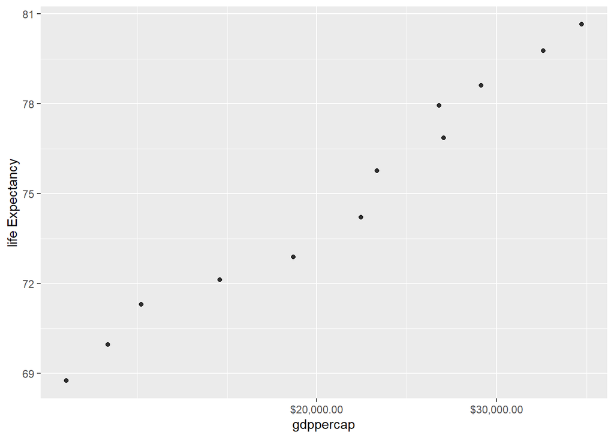

## Exercise 2: Explore individual variables with `dplyr`

#2.1 pick one categorical variable (continent) and one quantitative variable (gdpPercap). # First I plot the data to obtain a visual understanding of data. # The geom_point plot shows that the Maximum gdpPercap is in Asia and minimum is in africa, also based on data distribution we would expect higher Sd for Asia continent.

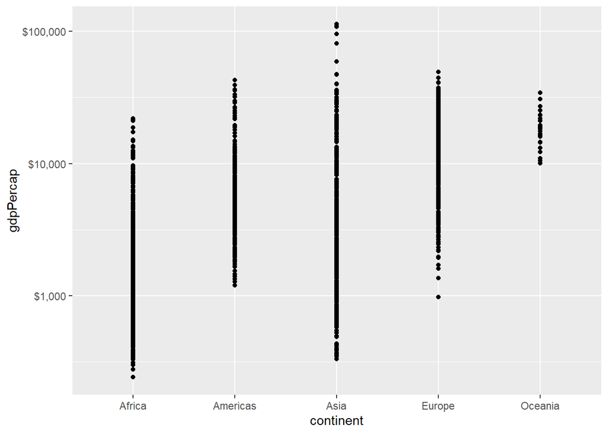

#2.2The table below reflects the data from geom_point plot.

```
## # A tibble: 5 x 6
##   continent max_gdp min_gdp mean_gdp median_gdp sd_gdp
##   <fct>       <dbl>   <dbl>    <dbl>      <dbl>  <dbl>
## 1 Africa     21951.    241.    2194.      1192.  2828.
## 2 Americas   42952.   1202.    7136.      5466.  6397.
## 3 Asia      113523.    331     7902.      2647. 14045.
## 4 Europe     49357.    974.   14469.     12082.  9355.
## 5 Oceania    34435.  10040.   18622.     17983.  6359.
```

## Exercise 3 Explore various plot types

#This is a scatterplot of continents life expectancy vs GDP per capita.

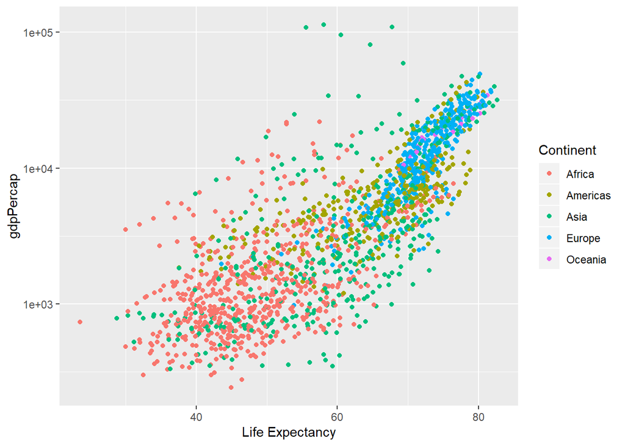

#3 2nd plot. This is a boxplot of the life expectancy of continents between 2003-2007

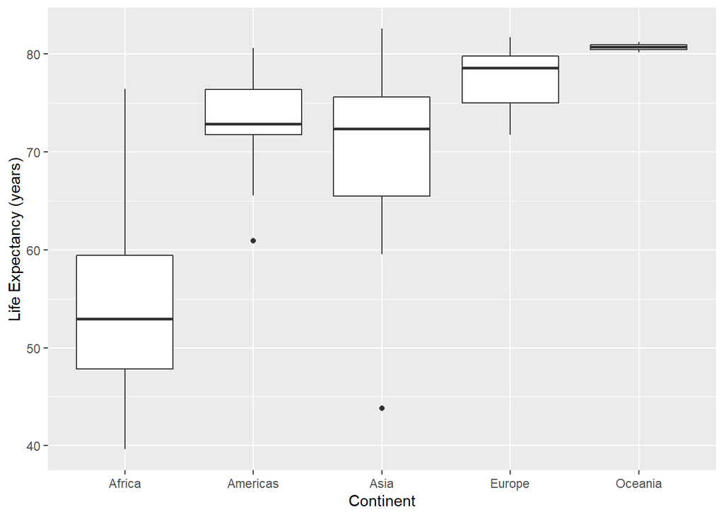